# EI-EP09-respuesta-equipo-7

### Confiabilidad de los modelos

7. Evaluar los modelos y “arreglarlos” en caso de que tengan algún problema con las condiciones que deben cumplir.

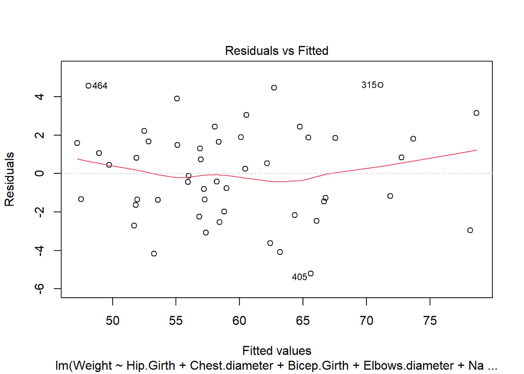

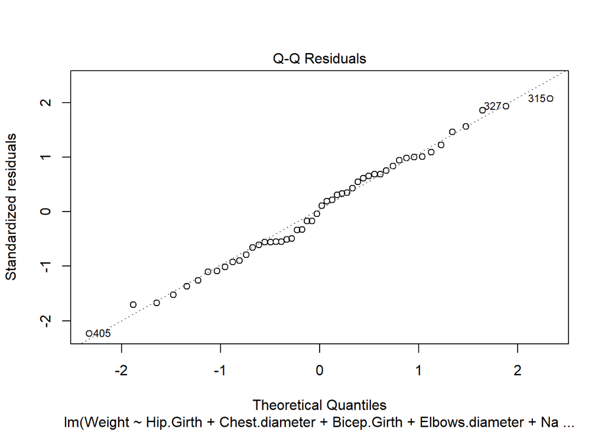

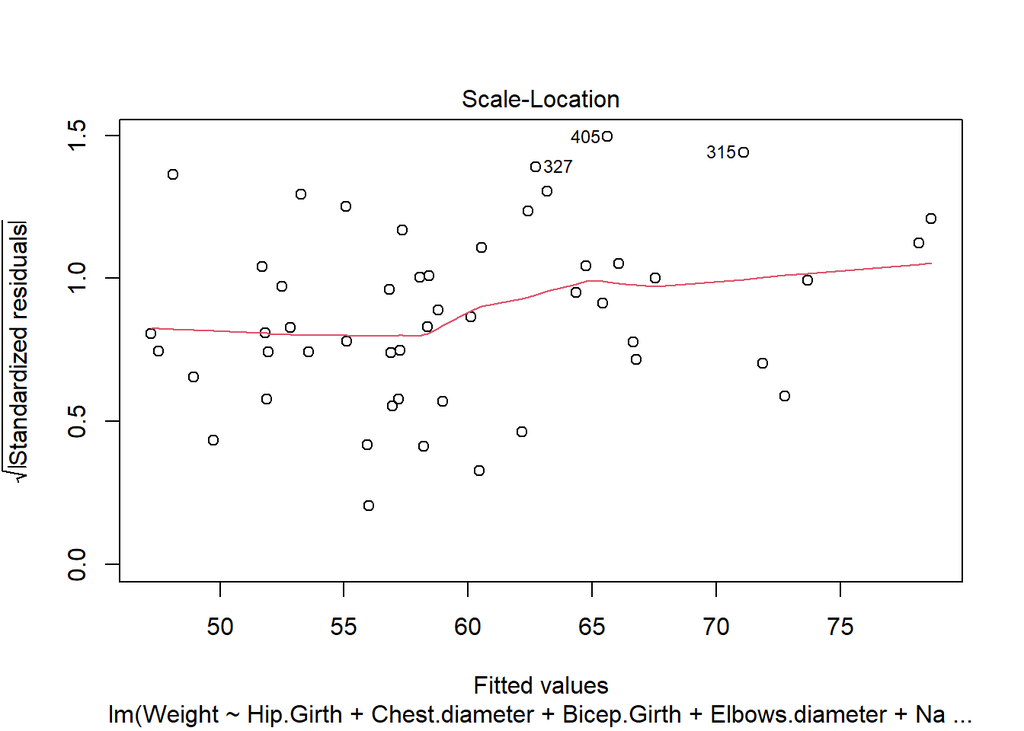

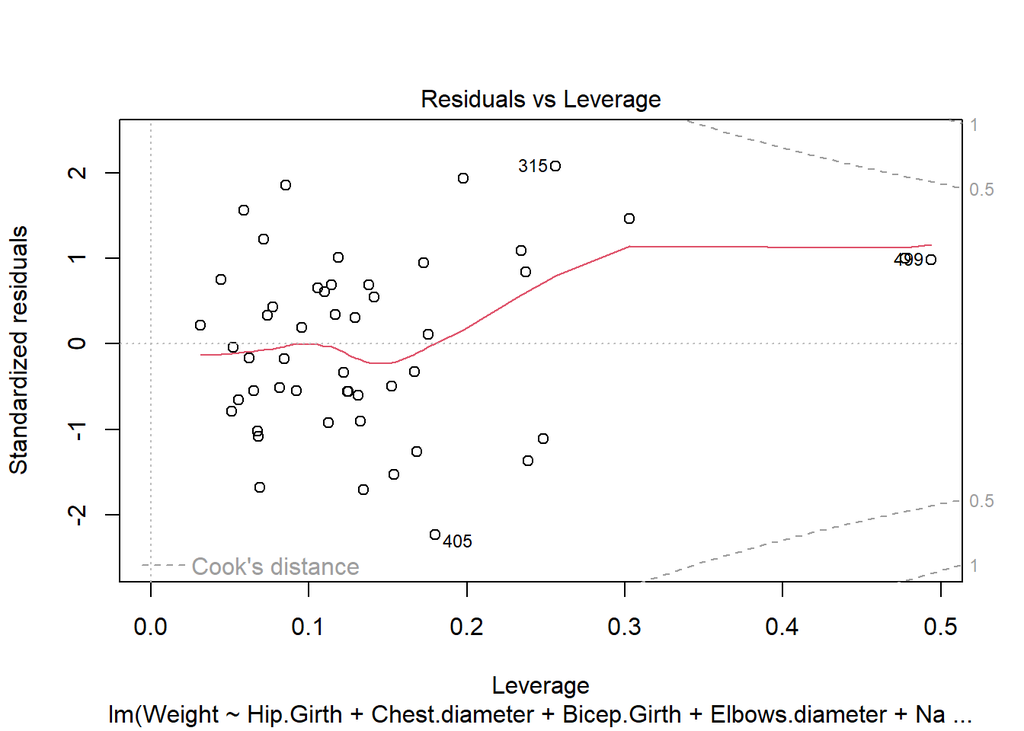

```r
# Evaluación modelo de regresión multiple obtenida previamente

plot(modelo_final)
```

```r
predictores <- names(coef(modelo_final))[-1]
datos_p <- muestra_m[, c(predictores, "Weight")]

resultados <- data.frame(respuesta_predicha = fitted(modelo_final))

resultados[["residuos_estandarizados"]] <- rstandard(modelo_final)
resultados[["residuos_estudiantizados"]] <- rstudent(modelo_final)
resultados[["distancia_Cook"]] <- cooks.distance(modelo_final)
resultados[["dfBeta"]] <- dfbeta(modelo_final)
resultados[["dffit"]] <- dffits(modelo_final)
resultados[["apalancamiento"]] <- hatvalues(modelo_final)
resultados[["covratio"]] <- covratio(modelo_final)

cat("Identificación de valores atípicos: \n")
```

```
## Identificación de valores atípicos:
```

```r
# Buscamos las observciones con residuos estandarizados fuera del 95% esperado
sospechoso1 <- which(abs(resultados[["residuos_estandarizados"]]) > 1.96)
cat("- Residuos estandarizados fuera del 95% esperado: ", sospechoso1, "\n")
```

```
## - Residuos estandarizados fuera del 95% esperado:  2 10
```

```r
# Buscamos observaciones con distancia de Cook mayor a 1
sospechoso2 <- which(resultados[["distancia_cook"]] > 1)
cat("- Residuos con una distancia de Cook alta:", sospechoso2, "\n")
```

```
## - Residuos con una distancia de Cook alta:
```

```r
# Buscamos observaciones con apalancamiento mayor igual al doble del apalacamiento promedio
apal_medio <- (ncol(datos_p) + 1) / nrow(datos_p)
sospechoso3 <- which(resultados[["apalancamiento"]] > 2 * apal_medio)
cat("- Residuos con apalancamiento fuera del rango: ", sospechoso3, "\n")
```

```
## - Residuos con apalancamiento fuera del rango:  18 21
```

```r
sospechoso4 <- which(apply(resultados[["dfBeta"]] >= 1, 1, any))
names(sospechoso4) <- NULL
cat("- Residuos con DFBeta >= 1:", sospechoso4, "\n")
```

```
## - Residuos con DFBeta >= 1: 7 15 20 22 23 36 43 44 48
```

```r
# Buscamos observaciones con razón de covarianza fuera de rango
inferior <- 1 - 3 * apal_medio
superior <- 1 + 3 * apal_medio
sospechoso5 <- which(resultados[["covratio"]] < inferior | resultados[["covratio"]] > superior)
cat("- Residuos con razón de covarianza fuera de rango: ", sospechoso5, "\n")
```

```
## - Residuos con razón de covarianza fuera de rango:  18 21
```

```r
# Resumen de valores sospechosos

sospechosos <- c(sospechoso1, sospechoso2, sospechoso3, sospechoso4, sospechoso5)

sospechosos <- sort(unique(sospechosos))

cat("\nResumen de valores sospechosos: \n")
```

```
##
## Resumen de valores sospechosos:
```

```r
cat("Apalancamiento promedio: ", apal_medio, "\n")
```

```
## Apalancamiento promedio:  0.16
```

```r
cat("Intervalo razón de covarianza: [", inferior, "; ", superior, "]\n\n", sep = "")
```

```
## Intervalo razón de covarianza: [0.52; 1.48]
```

```r
print(round(resultados[sospechosos, c("distancia_Cook", "apalancamiento", "covratio")], 3))
```

```
##     distancia_Cook apalancamiento covratio
## 315          0.212          0.256    0.757
## 419          0.065          0.135    0.836
## 405          0.157          0.180    0.606
## 375          0.052          0.235    1.267
## 328          0.131          0.478    1.914
## 464          0.046          0.086    0.718
## 499          0.135          0.494    1.985
## 371          0.061          0.154    0.943
## 362          0.022          0.059    0.832
## 357          0.008          0.131    1.278
## 302          0.083          0.239    1.137
## 385          0.007          0.106    1.231
## 257          0.046          0.169    1.089
```

Al analizar los resultados obtenidos, esto junto a los gráficos de la regresión, se puede observar algunas observaciones posee valores un tanto alto en lo que refiere a apalancamiento y covarianza, sin embargo, ninguna de las observaciones supera el valor recomendado de la distancia de Cook. Por lo tanto, podemos concluir que los datos analizados no presentan valores con sobreinfluencia, o no se tienen las justificaciones necesarias para modificarlos.

### Calidad predictiva de los modelos

8. Estimación del poder predictivo del modelo obtenido.

Para poder estimar el poder predictivo del modelo de regresión múltiple obtenido se realizará una validación cruzada, es específico una de 5 pliegues para obtener un mejor resultado.

```r
# Como conjunto de datos se utilizará los obtenidos en el paso anterior. (datos_p)

n <- nrow(datos_p)
n_entrenamiento <- floor(0.7 * n)

muestra <- sample.int(n = n, size = n_entrenamiento, replace = FALSE)
entrenamiento <- datos_p[muestra, ]
prueba <- datos_p[-muestra, ]

modelo_vc <- train(Weight ~ Hip.Girth + Knees.diameter + Bicep.Girth + Chest.diameter + Elbows.diameter + Navel.Girth, data = entrenamiento, method = "lm",
                   trControl = trainControl(method = "cv", number = 5))

summary(modelo_vc)
```

```
##
## Call:
## lm(formula = .outcome ~ ., data = dat)
##
## Residuals:
##     Min      1Q  Median      3Q     Max
## -3.5769 -1.5368 -0.4339  1.5932  4.2052
##
## Coefficients:
##                  Estimate Std. Error t value Pr(>|t|)
## (Intercept)     -76.47189    9.31591  -8.209 6.19e-09 ***
## Hip.Girth         0.51225    0.14519   3.528  0.00147 **
## Knees.diameter    0.99795    0.47728   2.091  0.04573 *
## Bicep.Girth       0.64702    0.23551   2.747  0.01039 *
## Chest.diameter    0.63014    0.28454   2.215  0.03510 *
## Elbows.diameter   1.87245    0.62541   2.994  0.00570 **
## Navel.Girth       0.14943    0.07594   1.968  0.05906 .
## ---
## Signif. codes:  0 '***' 0.001 '**' 0.01 '*' 0.05 '.' 0.1 ' ' 1
##
## Residual standard error: 2.204 on 28 degrees of freedom
## Multiple R-squared:  0.9463, Adjusted R-squared:  0.9348
## F-statistic: 82.25 on 6 and 28 DF,  p-value: < 2.2e-16
```

```r
predic_entrenamiento <- predict(modelo_vc, entrenamiento)
error_entrenamiento <- entrenamiento[["Weight"]] - predic_entrenamiento
mse_entrenamiento <- mean(error_entrenamiento ** 2)
cat("MSE para el conjunto de entrenamiento: ", mse_entrenamiento, "\n")
```

```
## MSE para el conjunto de entrenamiento:  3.885053
```

```r
predic_prueba <- predict(modelo_vc, prueba)
error_prueba <- prueba[["Weight"]] - predic_prueba
mse_prueba <- mean(error_prueba ** 2)
cat("MSE para el conjunto de prueba: ", mse_prueba, "\n")
```

```
## MSE para el conjunto de prueba:  12.58004
```